# Bayesian GLMM Part1

Author

Murray Logan

Published

21/08/2026

# 1 Preparations

Load the necessary libraries

```r
library(tidyverse)  #for data wrangling etc
library(cmdstanr)   #for cmdstan
library(brms)       #for fitting models in STAN
library(standist)   #for exploring distributions
library(HDInterval) #for HPD intervals
library(posterior)  #for posterior draws
library(coda)       #for diagnostics
library(bayesplot)  #for diagnostics
library(rstan)      #for interfacing with STAN
library(DHARMa)     #for residual diagnostics
library(emmeans)    #for marginal means etc
library(broom)      #for tidying outputs
library(broom.mixed) #for tidying MCMC outputs
library(tidybayes)  #for more tidying outputs
library(ggeffects)  #for partial plots
library(patchwork)  #for multiple figures
library(bayestestR) #for ROPE
library(ggridges)   #for ridge plots
library(easystats)     #framework for stats, modelling and visualisation
source('helperFunctions.R')
```

# 2 Scenario

A plant pathologist wanted to examine the effects of two different strengths of tobacco virus on the number of lesions on tobacco leaves. She knew from pilot studies that leaves were inherently very variable in response to the virus. In an attempt to account for this leaf to leaf variability, both treatments were applied to each leaf. Eight individual leaves were divided in half, with half of each leaf inoculated with weak strength virus and the other half inoculated with strong virus. So the leaves were blocks and each treatment was represented once in each block. A completely randomised design would have had 16 leaves, with 8 whole leaves randomly allocated to each treatment.

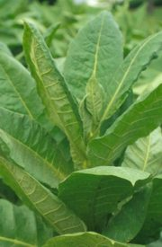

**Figure** 1: Tobacco plant

**Table** 1: Format of tobacco.csv data files

| LEAF | TREAT | NUMBER |
| --- | --- | --- |
| 1 | Strong | 35.898 |
| 1 | Weak | 25.02 |
| 2 | Strong | 34.118 |
| 2 | Weak | 23.167 |
| 3 | Strong | 35.702 |
| 3 | Weak | 24.122 |
| ... | ... | ... |

**Table** 2: Description of the variables in the tobacco data file

| **LEAF** | The blocking factor - Factor B |
| --- | --- |
| **TREAT** | Categorical representation of the strength of the tobacco virus - main factor of interest Factor A |
| **NUMBER** | Number of lesions on that part of the tobacco leaf - response variable |

# 3 Read in the data

```r
tobacco <- read_csv("../data/tobacco.csv", trim_ws = TRUE)
head(tobacco)
```

```
# A tibble: 6 × 3
  LEAF  TREATMENT NUMBER
  <chr> <chr>      <dbl>
1 L1    Strong      35.9
2 L1    Weak        25.0
3 L2    Strong      34.1
4 L2    Weak        23.2
5 L3    Strong      35.7
6 L3    Weak        24.1
```

```r
#LEAF is random effect (random effect is always categorical)
#NUMBER is response
#TREATMENT is fixed effect

tobacco <- tobacco |>
  mutate(LEAF = factor(LEAF),
         TREATMENT = factor(TREATMENT))

#NUMBER is averaged so we are looking at a normal distribution
```